# **Facial Emotion Detection**

## **Executive Summary**

This project proposes the Complex Neural Network model for automatically identifying the emotional state conveyed by a human's face from the images. The suggested model helps predict with high accuracy the emotions associated with the images. This model involves multiple convolution layers to help learn the train data and predict on the test data. Convolutional Neural Networks (CNNs) are highly recommended for image classification tasks due to their unique architecture, which is specifically designed to effectively capture spatial hierarchies and patterns in images. This model works well with four emotions currently: happy, sad, surprise and neutral. Additional emotions can be added to the dataset to help classify broader range of human emotions. It is recommended to maintain a balance in the dataset for all the emotions for accurate predictions. Imbalanced datasets can lead to biased models. This model can further be integrated with real-time facial emotion detection systems.

## **Summary of the problem - Explain the reason for the proposed solution design - How it would affect the problem/business?**

Different architecture of Convolution Neural Networks (CNNs) and Transfer Learning models were built and evaluated on the dataset. Three different CNNs models developed are Base Neural Network, Second CNN (bit complex than Base Neural Network) and the Complex Neural Network. Three Transfer Learning Architecture used are VGG16, ResNet V2 and EfficientNet to build the model.

Below is the comparison of the accuracies from all the models.

[figure not shown]

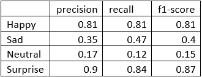

F1-scores are high for Happy and Surprise. From the heatmap we can observe that mostly the neutral images are predicted as sad.

Thus, proposing the Complex Neural Network model as it gives a higher accuracy. The computation cost and time for this model is less compared to the Transfer Learning models. It was observed during evaluation that the Transfer learning models are computationally expensive and takes more computation time per epoch.

## **What are some key recommendations to implement the solutions? - What are the key actionables for stakeholders? What is the expected benefit and/or costs? - What are the key risks and challenges? - What further analysis needs to be done or what other associated problems need to be solved?**

### **Key recommendations to implement the solutions**

To maintain a balance in the train and validation datasets for all the emotions for higher prediction accuracy in the test data.

To gather a diverse dataset that includes a wide range of facial expressions, genders, ages and ethnicities. This will help the model to predict well.

To be mindful of potential biases in the dataset, need to regularly assess and address biases to ensure fairness in the model prediction.

To consider that facial expressions evolve over time and user interaction may change. So, we need to have continuous improvement, monitoring and updating of the system that it can work well in dynamic environments.

### **Key actionables for stakeholders**

Prioritizing user privacy by implementing strong data protection measures and compliance with relevant privacy regulations.

Propose strong ethical guidelines for the development, deployment, and use of facial emotion detection systems.

Conduct risk assessments to identify potential ethical, legal risks associated with facial emotion detection, and implement strategies to mitigate these risks.

### **Expected benefit and/or costs**

Training and deploying sophisticated convolutional models may require significant computational resources.

If the train dataset is biased it can lead to inaccurate predictions across different demographics.

Integrating facial emotion detection system into an existing system or application may present technical challenges, and organizations may need to invest in integration efforts.

### **Key risks and challenges**

There is a high chance of the model being biased on the demographics of the training data, leading to inaccurate predictions, particularly across different ethnicities, genders, and age groups. To mitigate this, diverse training dataset is needed, and ongoing efforts to identify and address the biases.

Additionally, models trained on specific datasets may struggle to generalize well to diverse and dynamic real-world scenarios, leading to inaccurate predictions. Continuous improvement of model accuracy requires ongoing training with diverse datasets and addressing challenges like variations in expressions, and backgrounds.

Integrating facial emotion detection into existing systems or applications may face technical challenges, compatibility issues, and require significant adjustments. Ensuring seamless integration involves collaboration with IT teams and addressing compatibility issues with legacy systems.

### **Further analysis needs to be done**

Further analysis needs to be done to optimize the complex neural network model for even higher accuracy and to stop overfitting.

Additonally VGGFACE model can analyzed and its performance on the same dataset can be observed.

## **Problem Definition**

**The context:** Why is this problem important to solve?  
**The objectives:** What is the intended goal?  
**The key questions:** What are the key questions that need to be answered?  
**The problem formulation:** What are we trying to solve using data science?

## **About the dataset**

The data set consists of 3 folders, i.e., 'test', 'train', and 'validation'. Each of these folders has four subfolders:

**‘happy’**: Images of people who have happy facial expressions.  
**‘sad’**: Images of people with sad or upset facial expressions.  
**‘surprise’**: Images of people who have shocked or surprised facial expressions.  
**‘neutral’**: Images of people showing no prominent emotion in their facial expression at all.

**The context:** Why is this problem important to solve?

Facial emotion detection involves developing a model capable of recognizing and classifying human emotions based on facial expressions in images or video frames.This problem is very important to solve because it is very useful in many applications like Human - machine interaction, where systems can be enabled to respond to humans emotional state. It can be used in enhance customer experience in the stores, in educational systems to adapt to students emotional engagement, in health care to help identify depression, anxiety and several other applications.

**The objectives:** What is the intended goal?

The intended goal is to create a model that can automatically identify the emotional state conveyed by a person's face from images.

**The key questions:** What are the key questions that need to be answered?

1. What is the purpose of emotion detection?
2. Which deep learning model will be used?
3. What will be the train and test dataset?

**The problem formulation:** What are we trying to solve using data science?

This problem is typically approached as a computer vision and machine learning task, where we are trying to build a model using many complex deep learning models that can predict the emotions with high accuracy.

## **Mounting the Drive**

**NOTE:** Please use Google Colab from your browser for this notebook. **Google.colab is NOT a library that can be downloaded locally on your device.**

```python
from google.colab import drive
drive.mount('/content/drive')
```

## **Importing the Libraries**

```python
import numpy as np
import pandas as pd
import matplotlib.pyplot as plt
import os
import zipfile

# For Data Visualization
import cv2
import seaborn as sns

# For Model Building
import tensorflow as tf
import keras
from tensorflow.keras.models import Sequential, Model # Sequential API for sequential model
from tensorflow.keras.layers import Dense, Dropout, Flatten, GlobalAveragePooling2D # Importing different layers
from tensorflow.keras.layers import Conv2D, MaxPooling2D, BatchNormalization, Activation, Input, LeakyReLU, Activation
from tensorflow.keras import backend
from tensorflow.keras.utils import to_categorical # To perform one-hot encoding
from tensorflow.keras.optimizers import RMSprop, Adam, SGD # Optimizers for optimizing the model
from tensorflow.keras.callbacks import EarlyStopping  # Regularization method to prevent the overfitting
from tensorflow.keras.callbacks import ModelCheckpoint
from tensorflow.keras import losses, optimizers
from tensorflow.keras.preprocessing.image import load_img
from tensorflow.keras.preprocessing.image import ImageDataGenerator
from google.colab.patches import cv2_imshow
from tensorflow.keras import regularizers
```

### **Let us load and unzip the data**

**Note:**

- You must download the dataset from the link provided on Olympus and upload the same on your Google drive before executing the code in the next cell.
- In case of any error, please make sure that the path of the file is correct as the path may be different for you.

```python
# Storing the path of the data file from the Google drive
path = '/content/drive/MyDrive/DSML/Project/Capstone/Facial_emotion_images.zip'

# Extract the files from the zip file
with zipfile.ZipFile(path, 'r') as zip_ref:
    zip_ref.extractall()
```

## **Visualizing our Classes**

Let's look at our classes.

**Write down your observation for each class. What do you think can be a unique feature of each emotion, that separates it from the remaining classes?**

### **Happy**

```python
TrainData = "/content/Facial_emotion_images/train"                                # Path of training data after unzipping
Categories = ["happy", "sad", "surprise", "neutral"]                              # Storing all the categories in 'CATEGORIES' variable
```

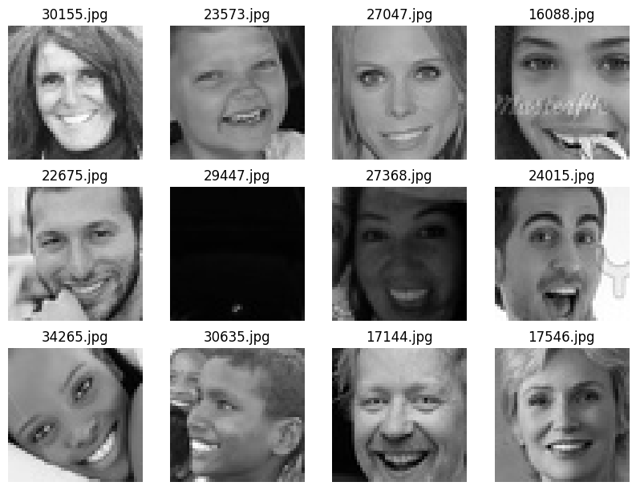

```python
happy_images = [fn for fn in os.listdir(f'{TrainData}/{Categories[0]}') ]
happy_ran_img = np.random.choice(happy_images, 13, replace = False)
fig = plt.figure(figsize = (10, 10))
for i in range(12):
    ax = fig.add_subplot(4, 4, i + 1)
    ax.set_title(happy_ran_img[i])
    fp = f'{TrainData}/{Categories[0]}/{happy_ran_img[i]}'
    fn = load_img(fp, target_size = (48, 48))
    plt.imshow(fn, cmap = 'Greys_r')
    plt.axis('off')
plt.show()
```

**Observations and Insights:__**

From the above images we can conclude that all the images that has a smiling face is considered as "Happy", which is true by human emotions. Happy emotion is easy to classify. We can see in one of the image 29447.img that face is not very clear, hence we cannot be sure if this image can be classified as happy.

### **Sad**

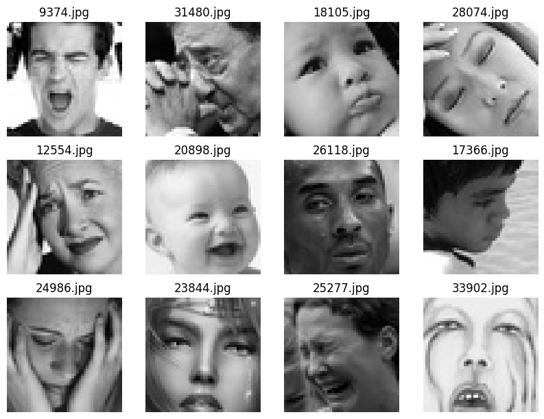

```python
sad_images = [fn for fn in os.listdir(f'{TrainData}/{Categories[1]}') ]
sad_ran_img = np.random.choice(sad_images, 13, replace = False)
fig = plt.figure(figsize = (10, 10))
for i in range(12):
    ax = fig.add_subplot(4, 4, i + 1)
    ax.set_title(sad_ran_img[i])
    fp = f'{TrainData}/{Categories[1]}/{sad_ran_img[i]}'
    fn = load_img(fp, target_size = (48, 48))
    plt.imshow(fn, cmap = 'Greys_r')
    plt.axis('off')
plt.show()
```

**Observations and Insights:__**

From the above images we can conclude that all the images that has a tear or pain in the facial emotion is considered as "sad". But looks like there are misclassifications in the train dataset as 20898.jpg does not look sad, but rather looks happy.

### **Surprise**

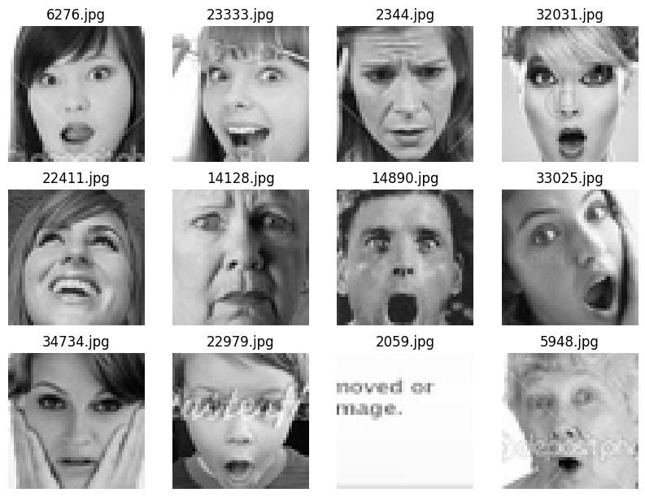

```python
surprise_images = [fn for fn in os.listdir(f'{TrainData}/{Categories[2]}') ]
surprise_ran_img = np.random.choice(surprise_images, 13, replace = False)
fig = plt.figure(figsize = (10, 10))
for i in range(12):
    ax = fig.add_subplot(4, 4, i + 1)
    ax.set_title(surprise_ran_img[i])
    fp = f'{TrainData}/{Categories[2]}/{surprise_ran_img[i]}'
    fn = load_img(fp, target_size = (48, 48))
    plt.imshow(fn, cmap = 'Greys_r')
    plt.axis('off')
plt.show()
```

**Observations and Insights:__**

From the above images we can conclude that all the images show surprised look is considered as "surprise". Surprise emotion can be a bit challenging emotion to capture. The train dataset does have some images like 2059.jpg, which does not contain face, which is misclassified.

### **Neutral**

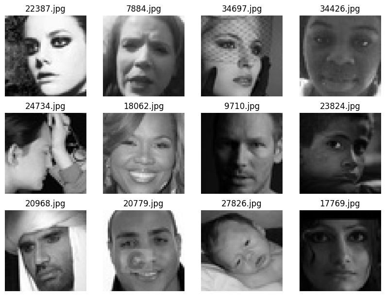

```python
neutral_images = [fn for fn in os.listdir(f'{TrainData}/{Categories[3]}') ]
neutral_ran_img = np.random.choice(neutral_images, 13, replace = False)
fig = plt.figure(figsize = (10, 10))
for i in range(12):
    ax = fig.add_subplot(4, 4, i + 1)
    ax.set_title(neutral_ran_img[i])
    fp = f'{TrainData}/{Categories[3]}/{neutral_ran_img[i]}'
    fn = load_img(fp, target_size = (150, 150))
    plt.imshow(fn, cmap = 'Greys_r')
    plt.axis('off')
plt.show()
```

**Observations and Insights:__**

From the above images we can conclude that all the images that does no show any emotion is considered as "neutral". But looks like there are misclassifications in the train dataset as 18062.jpg does look happy.

## **Checking Distribution of Classes**

```python
# Count of images in each folder within the training path
happy = len(os.listdir(f'{TrainData}/{Categories[0]}'))
print("Number of images in class 'happy': ", happy)

sad = len(os.listdir(f'{TrainData}/{Categories[1]}'))
print("Number of images in class 'sad': ", sad)

surprise = len(os.listdir(f'{TrainData}/{Categories[2]}'))
print("Number of images in class 'surprise': ", surprise)

neutral = len(os.listdir(f'{TrainData}/{Categories[3]}'))
print("Number of images in class 'neutral': ", neutral)
```

```
Number of images in class 'happy':  3976
Number of images in class 'sad':  3982
Number of images in class 'surprise':  3173
Number of images in class 'neutral':  3978
```

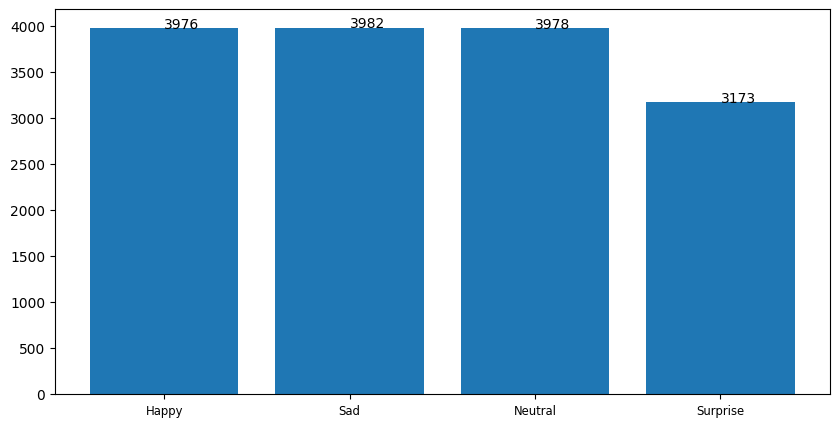

```python
# Plotting the histogram
def addlabels(x,y):
    for i in range(len(x)):
        plt.text(i,y[i],y[i])

plt.figure(figsize = (10, 5))
data = {'Happy': happy, 'Sad': sad, 'Neutral': neutral, 'Surprise' : surprise}
df = pd.Series(data)
plt.bar(range(len(df)), df.values, align = 'center')
addlabels(range(len(df)), df.values)
plt.xticks(range(len(df)), df.index.values, size = 'small')
plt.show()
```

**Observations and Insights:__**

There are total of 15109 images in train dataset. There are 3976 images classified as Happy, 3982 images classified as Sad, 3978 images classified as Neutral and 3173 classified as Surprise. From the above distribution we can see that Surprise has bit lower number of images, but imbalance is low.

**Think About It:**

- Are the classes equally distributed? If not, do you think the imbalance is too high? Will it be a problem as we progress?
- Are there any Exploratory Data Analysis tasks that we can do here? Would they provide any meaningful insights?

## **Creating our Data Loaders**

In this section, we are creating data loaders that we will use as inputs to our Neural Network.

**You have two options for the color_mode. You can set it to color_mode = 'rgb' or color_mode = 'grayscale'. You will need to try out both and see for yourself which one gives better performance.**

##### **Grayscale data loaders**

```python
# Grayscale data loader

batch_size  = 128
img_size = 48

datagen_train  = ImageDataGenerator(rescale = 1./255)

train_set = datagen_train.flow_from_directory("/content/Facial_emotion_images/train",
                                              target_size = (img_size, img_size),
                                              color_mode = "grayscale" ,
                                              batch_size = batch_size,
                                              class_mode = 'categorical',
                                              shuffle = True)

datagen_val  = ImageDataGenerator(rescale = 1./255)

validation_generator =  datagen_val.flow_from_directory("/content/Facial_emotion_images/validation",
                                                         batch_size=batch_size,
                                                         color_mode = "grayscale" ,
                                                         class_mode  = 'categorical',
                                                         target_size = (img_size, img_size),
                                                        )

datagen_test  = ImageDataGenerator(rescale = 1./255)

test_generator =  datagen_test.flow_from_directory("/content/Facial_emotion_images/test",
                                                         batch_size=batch_size,
                                                         color_mode = "grayscale" ,
                                                         class_mode  = 'categorical',
                                                         target_size = (img_size, img_size),
                                                   )
```

```
Found 15109 images belonging to 4 classes.
Found 4977 images belonging to 4 classes.
Found 128 images belonging to 4 classes.
```

##### **RGB data loaders**

```python
# RGB data loader
batch_size  = 128
img_size = 48

rgb_datagen_train = ImageDataGenerator(horizontal_flip = True,
                                       brightness_range=(0.,2.),
                                       rescale=1./255,
                                       shear_range=0.3)

rgb_train_set = rgb_datagen_train.flow_from_directory("/content/Facial_emotion_images/train",
                                              target_size = (img_size, img_size),
                                              color_mode = "rgb" ,
                                              batch_size = batch_size,
                                              class_mode = 'categorical',
                                              shuffle = True)

rgb_datagen_val  = ImageDataGenerator(rescale = 1.0/255.)

rgb_validation_generator =  rgb_datagen_val.flow_from_directory("/content/Facial_emotion_images/validation",
                                                         batch_size=batch_size,
                                                        color_mode = "rgb" ,
                                                         class_mode  = 'categorical',
                                                         target_size = (img_size, img_size))

rgb_datagen_test  = ImageDataGenerator(rescale = 1.0/255.)

rgb_test_generator =  rgb_datagen_test.flow_from_directory("/content/Facial_emotion_images/test",
                                                         batch_size=batch_size,
                                                        color_mode = "rgb" ,
                                                         class_mode  = 'categorical',
                                                         target_size = (img_size, img_size))
```

```
Found 15109 images belonging to 4 classes.
Found 4977 images belonging to 4 classes.
Found 128 images belonging to 4 classes.
```

## **Model Building**

**Think About It:**

- Are Convolutional Neural Networks the right approach? Should we have gone with Artificial Neural Networks instead?
- What are the advantages of CNNs over ANNs and are they applicable here?

### **Creating the Base Neural Network**

#### **Grayscale**

```python
from tensorflow.keras import backend
backend.clear_session()

# Fixing the seed for random number generators so that we can ensure we receive the same output everytime
np.random.seed(42)
import random
random.seed(42)
tf.random.set_seed(42)
```

```python
# Intializing a sequential model
cnn1_gs_model = Sequential()

# Adding first conv layer with 64 filters and kernel size 2x2, padding 'same' followed by a Maxpooling2D layer and Dropout
cnn1_gs_model.add(Conv2D(64, (2, 2), activation = 'relu', padding = "same", input_shape = (48, 48, 1)))
cnn1_gs_model.add(MaxPooling2D(2, 2))
cnn1_gs_model.add(Dropout(0.2))

# Adding second conv layer with 32 filters and kernel size 2x2, padding 'same' followed by a Maxpooling2D layer and Dropout
cnn1_gs_model.add(Conv2D(32, (2, 2), activation = 'relu', padding = "same"))
cnn1_gs_model.add(MaxPooling2D(2, 2))
cnn1_gs_model.add(Dropout(0.2))

# Add third conv layer with 32 filters and kernel size 2x2, padding 'same' followed by a Maxpooling2D layer and Dropout
cnn1_gs_model.add(Conv2D(32, (2, 2), activation='relu', padding="same"))
cnn1_gs_model.add(MaxPooling2D(2, 2))
cnn1_gs_model.add(Dropout(0.2))

# Flattening the output of the conv layer after max pooling to make it ready for creating dense connections
cnn1_gs_model.add(Flatten())

# Adding a fully connected dense layer with 512 neurons
cnn1_gs_model.add(Dense(512, activation = 'relu'))
cnn1_gs_model.add(Dropout(0.4))

# Adding the output layer with 4 neurons and activation functions as softmax since this is a multi-class classification problem
cnn1_gs_model.add(Dense(4, activation = 'softmax'))

# Generating the summary of the model
cnn1_gs_model.summary()
```

```
Model: "sequential"
_________________________________________________________________
 Layer (type)                Output Shape              Param #
=================================================================
 conv2d (Conv2D)             (None, 48, 48, 64)        320

 max_pooling2d (MaxPooling2  (None, 24, 24, 64)        0
 D)

 dropout (Dropout)           (None, 24, 24, 64)        0

 conv2d_1 (Conv2D)           (None, 24, 24, 32)        8224

 max_pooling2d_1 (MaxPoolin  (None, 12, 12, 32)        0
 g2D)

 dropout_1 (Dropout)         (None, 12, 12, 32)        0

 conv2d_2 (Conv2D)           (None, 12, 12, 32)        4128

 max_pooling2d_2 (MaxPoolin  (None, 6, 6, 32)          0
 g2D)

 dropout_2 (Dropout)         (None, 6, 6, 32)          0

 flatten (Flatten)           (None, 1152)              0

 dense (Dense)               (None, 512)               590336

 dropout_3 (Dropout)         (None, 512)               0

 dense_1 (Dense)             (None, 4)                 2052

=================================================================
Total params: 605060 (2.31 MB)
Trainable params: 605060 (2.31 MB)
Non-trainable params: 0 (0.00 Byte)
_________________________________________________________________
```

##### **Compiling and Training the Model**

```python
from keras.callbacks import ModelCheckpoint, EarlyStopping, ReduceLROnPlateau

# The following lines of code saves the best model's parameters if training accuracy goes down on further training
early_stopping = EarlyStopping(monitor = 'val_loss', mode = 'min', verbose = 1, patience = 3, min_delta = 0, restore_best_weights = True,)
checkpoint = ModelCheckpoint('best_model.h5', monitor = 'val_accuracy', mode = 'max', verbose = 1, save_best_only = True)
reduce_learningrate = ReduceLROnPlateau(monitor = 'val_loss', factor = 0.2, patience = 3, verbose = 1, min_delta = 0.0001, mode = "min")

callbacks_list = [early_stopping, checkpoint, reduce_learningrate]
```

```python
#Compiling the model using Adam Optimizer
opt = Adam(learning_rate = 0.001)

# Compiling the model
cnn1_gs_model.compile(optimizer = opt, loss = 'categorical_crossentropy', metrics = ['accuracy'])
```

```python
# Pulling a single large batch of random testing data for testing after each epoch
testX, testY = validation_generator.next()
```

```python
# Fit the model
cnn1_gs_model_history = cnn1_gs_model.fit(train_set,
                              validation_data=(testX, testY),
                              epochs=20,
                              callbacks = callbacks_list)
```

```
Epoch 1: val_accuracy improved from -inf to 0.33594, saving model to best_model.h5
```

```
Epoch 2: val_accuracy improved from 0.33594 to 0.50781, saving model to best_model.h5
Epoch 3: val_accuracy improved from 0.50781 to 0.54688, saving model to best_model.h5
Epoch 4: val_accuracy improved from 0.54688 to 0.56250, saving model to best_model.h5
Epoch 5: val_accuracy improved from 0.56250 to 0.60156, saving model to best_model.h5
Epoch 6: val_accuracy did not improve from 0.60156
Epoch 7: val_accuracy improved from 0.60156 to 0.61719, saving model to best_model.h5
Epoch 8: val_accuracy improved from 0.61719 to 0.62500, saving model to best_model.h5
Epoch 9: val_accuracy did not improve from 0.62500
Epoch 10: val_accuracy improved from 0.62500 to 0.64062, saving model to best_model.h5
Epoch 11: val_accuracy improved from 0.64062 to 0.66406, saving model to best_model.h5
Epoch 12: val_accuracy did not improve from 0.66406
Epoch 13: val_accuracy did not improve from 0.66406
Epoch 14: val_accuracy improved from 0.66406 to 0.67969, saving model to best_model.h5
Epoch 15: val_accuracy did not improve from 0.67969
Epoch 16: val_accuracy improved from 0.67969 to 0.68750, saving model to best_model.h5
Epoch 17: val_accuracy did not improve from 0.68750
Epoch 18: val_accuracy did not improve from 0.68750
Epoch 19: val_accuracy improved from 0.68750 to 0.71875, saving model to best_model.h5
Epoch 20: val_accuracy did not improve from 0.71875
```

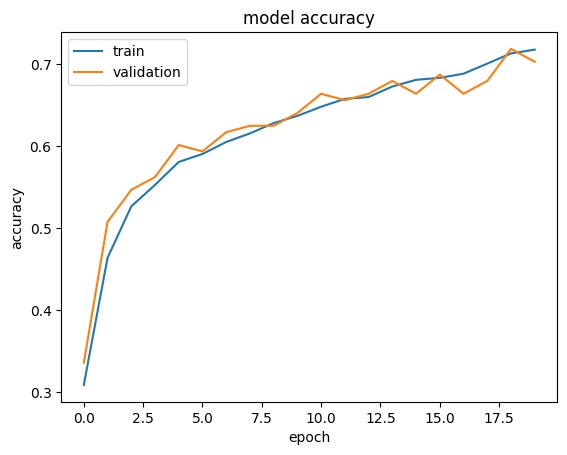

```python
# Plotting the training and validation accuracies for each epoch
N = len(cnn1_gs_model_history.history["accuracy"])
#plt.figure(figsize = (10,6))
plt.plot(np.arange(0, N),cnn1_gs_model_history.history['accuracy'])
plt.plot(np.arange(0, N),cnn1_gs_model_history.history['val_accuracy'])
#plt.ylim(0, 1)
plt.title('model accuracy')
plt.ylabel('accuracy')
plt.xlabel('epoch')
plt.legend(['train', 'validation'], loc='upper left')
plt.show()
```

##### **Evaluating the Model on the Test Set**

```python
# Evaluating on the Test dataset
cnn1_gs_model.evaluate(test_generator)
```

```
[0.7371190190315247, 0.703125]
```

**Observations and Insights:__**

From the grayscale base model we can observe that both the train and validation accuracy is around 70%. When evaluated on test datset the accuracy remains around 70%.

#### **RGB**

```python
from tensorflow.keras import backend
backend.clear_session()

# Fixing the seed for random number generators so that we can ensure we receive the same output everytime
np.random.seed(42)
import random
random.seed(42)
tf.random.set_seed(42)
```

```python
# Intializing a sequential model
cnn1_rgb_model = Sequential()

# Adding first conv layer with 64 filters and kernel size 2x2, padding 'same' followed by a Maxpooling2D layer and Dropout
cnn1_rgb_model.add(Conv2D(64, (2, 2), activation = 'relu', padding = "same", input_shape = (48, 48, 3)))
cnn1_rgb_model.add(MaxPooling2D((2, 2), padding = 'same'))
cnn1_rgb_model.add(Dropout(0.2))

# Adding second conv layer with 32 filters and kernel size 2x2, padding 'same' followed by a Maxpooling2D layer and Dropout
cnn1_rgb_model.add(Conv2D(32, (2, 2), activation = 'relu', padding = "same"))
cnn1_rgb_model.add(MaxPooling2D((2, 2), padding = 'same'))
cnn1_rgb_model.add(Dropout(0.2))

# Add third conv layer with 32 filters and kernel size 3x3, padding 'same' followed by a Maxpooling2D layer and Dropout
cnn1_rgb_model.add(Conv2D(32, (2, 2), activation='relu', padding="same"))
cnn1_rgb_model.add(MaxPooling2D((2, 2), padding = 'same'))
cnn1_rgb_model.add(Dropout(0.2))

# Flattening the output of the conv layer after max pooling to make it ready for creating dense connections
cnn1_rgb_model.add(Flatten())

# Adding a fully connected dense layer with 512 neurons
cnn1_rgb_model.add(Dense(512, activation = 'relu'))
cnn1_rgb_model.add(Dropout(0.2))

# Adding the output layer with 4 neurons and activation functions as softmax since this is a multi-class classification problem
cnn1_rgb_model.add(Dense(4, activation = 'softmax'))

# Generating the summary of the model
cnn1_rgb_model.summary()
```

[output not shown]

##### **Compiling and Training the Model**

```python
from keras.callbacks import ModelCheckpoint, EarlyStopping, ReduceLROnPlateau

# The following lines of code saves the best model's parameters if training accuracy goes down on further training
early_stopping = EarlyStopping(monitor = 'val_loss', mode = 'min', verbose = 1, patience = 3, min_delta = 0, restore_best_weights = True,)
checkpoint = ModelCheckpoint('best_model.h5', monitor = 'val_accuracy', mode = 'max', verbose = 1, save_best_only = True)
reduce_learningrate = ReduceLROnPlateau(monitor = 'val_loss', factor = 0.2, patience = 3, verbose = 1, min_delta = 0.0001, mode = "min")

callbacks_list = [early_stopping, checkpoint, reduce_learningrate]
```

```python
#Compiling the model using Adam Optimizer
opt = Adam(learning_rate = 0.001)

# Compiling the model
cnn1_rgb_model.compile(optimizer = opt, loss = 'categorical_crossentropy', metrics = ['accuracy'])
```

```python
# Pulling a single large batch of random testing data for testing after each epoch
testX, testY = rgb_validation_generator.next()
```

```python
# Fit the model
cnn1_rgb_model_history = cnn1_rgb_model.fit(rgb_train_set,
                              validation_data=(testX, testY),
                              epochs=20, callbacks = callbacks_list)
```

```
Epoch 1: val_accuracy improved from -inf to 0.45312, saving model to best_model.h5
Epoch 2: val_accuracy improved from 0.45312 to 0.50000, saving model to best_model.h5
Epoch 3: val_accuracy improved from 0.50000 to 0.58594, saving model to best_model.h5
Epoch 4: val_accuracy improved from 0.58594 to 0.59375, saving model to best_model.h5
Epoch 5: val_accuracy did not improve from 0.59375
Epoch 6: val_accuracy improved from 0.59375 to 0.64062, saving model to best_model.h5
Epoch 7: val_accuracy did not improve from 0.64062
Epoch 8: val_accuracy improved from 0.64062 to 0.66406, saving model to best_model.h5
Epoch 9: val_accuracy did not improve from 0.66406
Epoch 10: val_accuracy improved from 0.66406 to 0.67188, saving model to best_model.h5
Epoch 11: val_accuracy improved from 0.67188 to 0.68750, saving model to best_model.h5
Epoch 12: val_accuracy improved from 0.68750 to 0.71094, saving model to best_model.h5
Epoch 13: val_accuracy improved from 0.71094 to 0.71875, saving model to best_model.h5
Epoch 14: val_accuracy improved from 0.71875 to 0.74219, saving model to best_model.h5
Epoch 15: val_accuracy did not improve from 0.74219
Epoch 16: val_accuracy did not improve from 0.74219
Epoch 17: val_accuracy did not improve from 0.74219
Epoch 18: val_accuracy did not improve from 0.74219
Epoch 19: val_accuracy did not improve from 0.74219
Epoch 20: val_accuracy did not improve from 0.74219
```

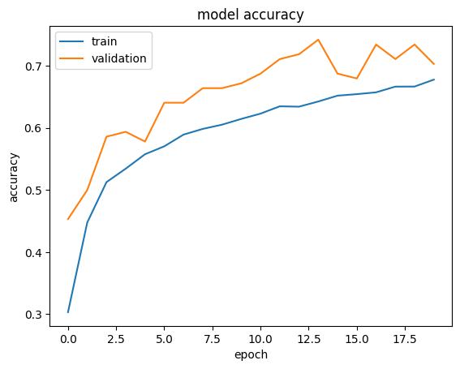

```python
# Plotting the training and validation accuracies for each epoch
N = len(cnn1_rgb_model_history.history["accuracy"])
#plt.figure(figsize = (10,6))
plt.plot(np.arange(0, N),cnn1_rgb_model_history.history['accuracy'])
plt.plot(np.arange(0, N),cnn1_rgb_model_history.history['val_accuracy'])
#plt.ylim(0, 1)
plt.title('model accuracy')
plt.ylabel('accuracy')
plt.xlabel('epoch')
plt.legend(['train', 'validation'], loc='upper left')
plt.show()
```

##### **Evaluating the Model on the Test Set**

```python
# Evaluating on the Test dataset
cnn1_rgb_model.evaluate(rgb_test_generator)
```

```
[0.7042044997215271, 0.671875]
```

**Observations and Insights:__**

### **Creating the second Convolutional Neural Network**

#### **Grayscale**

```python
from tensorflow.keras import backend
backend.clear_session()

# Fixing the seed for random number generators so that we can ensure we receive the same output everytime
np.random.seed(42)
import random
random.seed(42)
tf.random.set_seed(42)
```

- Try out a slightly larger architecture

```python
# Intializing a sequential model
cnn2_gs_model = Sequential()

# Adding first conv layer with 256 filters and kernel size 2x2, padding 'same' followed by a BatchNormalization, LeakyReLU and Maxpooling2D layer
cnn2_gs_model.add(Conv2D(256, (2, 2), activation = 'relu', padding = "same", input_shape = (48, 48, 1)))
cnn2_gs_model.add(BatchNormalization())
cnn2_gs_model.add(LeakyReLU(0.1))
cnn2_gs_model.add(MaxPooling2D(2, 2))

# Adding second conv layer with 128 filters and kernel size 2x2, padding 'same' followed by a BatchNormalization, LeakyReLU and Maxpooling2D layer
cnn2_gs_model.add(Conv2D(128, (2, 2), activation = 'relu', padding = "same"))
cnn2_gs_model.add(BatchNormalization())
cnn2_gs_model.add(LeakyReLU(0.1))
cnn2_gs_model.add(MaxPooling2D(2, 2))

# Add third conv layer with 64 filters and kernel size 2x2, padding 'same' followed by a BatchNormalization, LeakyReLU and Maxpooling2D layer
cnn2_gs_model.add(Conv2D(64, (2, 2), activation = 'relu', padding = "same"))
cnn2_gs_model.add(BatchNormalization())
cnn2_gs_model.add(LeakyReLU(0.1))
cnn2_gs_model.add(MaxPooling2D(2, 2))

# Add fourth conv layer with 32 filters and kernel size 2x2, padding 'same'
cnn2_gs_model.add(Conv2D(32, (2, 2), activation = 'relu', padding = "same"))

# Flattening the output of the conv layer after max pooling to make it ready for creating dense connections
cnn2_gs_model.add(Flatten())

# Adding a fully connected dense layer with 512 neurons
cnn2_gs_model.add(Dense(512, activation = 'relu'))

# Adding a fully connected dense layer with 128 neurons
cnn2_gs_model.add(Dense(128, activation = 'relu'))

# Adding the output layer with 4 neurons and activation functions as softmax since this is a multi-class classification problem
cnn2_gs_model.add(Dense(4, activation = 'softmax'))

# Generating the summary of the model
cnn2_gs_model.summary()
```

```
Model: "sequential"
_________________________________________________________________
 Layer (type)                Output Shape              Param #
=================================================================
 conv2d (Conv2D)             (None, 48, 48, 256)       1280

 batch_normalization (Batch  (None, 48, 48, 256)       1024
 Normalization)

 leaky_re_lu (LeakyReLU)     (None, 48, 48, 256)       0

 max_pooling2d (MaxPooling2  (None, 24, 24, 256)       0
 D)

 conv2d_1 (Conv2D)           (None, 24, 24, 128)       131200

 batch_normalization_1 (Bat  (None, 24, 24, 128)       512
 chNormalization)

 leaky_re_lu_1 (LeakyReLU)   (None, 24, 24, 128)       0

 max_pooling2d_1 (MaxPoolin  (None, 12, 12, 128)       0
 g2D)

 conv2d_2 (Conv2D)           (None, 12, 12, 64)        32832

 batch_normalization_2 (Bat  (None, 12, 12, 64)        256
 chNormalization)

 leaky_re_lu_2 (LeakyReLU)   (None, 12, 12, 64)        0

 max_pooling2d_2 (MaxPoolin  (None, 6, 6, 64)          0
 g2D)

 conv2d_3 (Conv2D)           (None, 6, 6, 32)          8224

 flatten (Flatten)           (None, 1152)              0

 dense (Dense)               (None, 512)               590336

 dense_1 (Dense)             (None, 128)               65664

 dense_2 (Dense)             (None, 4)                 516

=================================================================
Total params: 831844 (3.17 MB)
Trainable params: 830948 (3.17 MB)
Non-trainable params: 896 (3.50 KB)
_________________________________________________________________
```

##### **Compiling and Training the Model**

```python
from keras.callbacks import ModelCheckpoint, EarlyStopping, ReduceLROnPlateau

# The following lines of code saves the best model's parameters if training accuracy goes down on further training
early_stopping = EarlyStopping(monitor = 'val_loss', mode = 'min', verbose = 1, patience = 3, min_delta = 0, restore_best_weights = True,)
checkpoint = ModelCheckpoint('best_model.h5', monitor = 'val_accuracy', mode = 'max', verbose = 1, save_best_only = True)
#reduce_learningrate = ReduceLROnPlateau(monitor = 'val_loss', factor = 0.2, patience = 3, verbose = 1, min_delta = 0.0001, mode = "min")

callbacks_list = [early_stopping, checkpoint]
```

```python
#Compiling the model using Adam Optimizer
opt = Adam(learning_rate = 0.001)

# Compiling the model
cnn2_gs_model.compile(optimizer = opt, loss = 'categorical_crossentropy', metrics = ['accuracy'])
```

```python
# Pulling a single large batch of random testing data for testing after each epoch
testX, testY = validation_generator.next()
```

```python
# Fit the model
cnn2_gs_model_history = cnn2_gs_model.fit(train_set,
                              validation_data=(testX, testY),
                              epochs=20
                                          #, callbacks = callbacks_list
                                          )
```

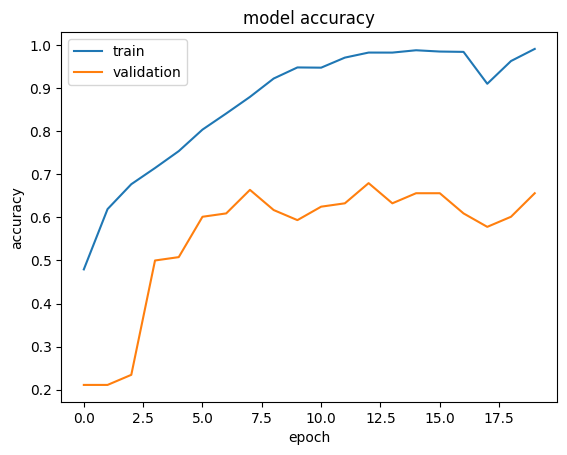

```python
# Plotting the training and validation accuracies for each epoch
N = len(cnn2_gs_model_history.history["accuracy"])
#plt.figure(figsize = (10,6))
plt.plot(np.arange(0, N),cnn2_gs_model_history.history['accuracy'])
plt.plot(np.arange(0, N),cnn2_gs_model_history.history['val_accuracy'])
#plt.ylim(0, 1)
plt.title('model accuracy')
plt.ylabel('accuracy')
plt.xlabel('epoch')
plt.legend(['train', 'validation'], loc='upper left')
plt.show()
```

##### **Evaluating the Model on the Test Set**

```python
# Evaluating on the Test dataset
cnn2_gs_model.evaluate(test_generator)
```

```
[1.992957353591919, 0.6640625]
```

**Observations and Insights:__**

From the grayscale model, the validation accuracy is around 65%. The test accuracy is 66%. From the plot we can observe overfitting.

#### **RGB**

```python
from tensorflow.keras import backend
backend.clear_session()

# Fixing the seed for random number generators so that we can ensure we receive the same output everytime
np.random.seed(42)
import random
random.seed(42)
tf.random.set_seed(42)
```

```python
# Intializing a sequential model
cnn2_rgb_model = Sequential()

# Adding first conv layer with 256 filters and kernel size 2x2, padding 'same' followed by a BatchNormalization, LeakyReLU and Maxpooling2D layer
cnn2_rgb_model.add(Conv2D(256, (2, 2), activation = 'relu', padding = "same", input_shape = (48, 48, 3)))
cnn2_rgb_model.add(BatchNormalization())
cnn2_rgb_model.add(LeakyReLU(0.1))
cnn2_rgb_model.add(MaxPooling2D(2, 2))

# Adding second conv layer with 128 filters and kernel size 2x2, padding 'same' followed by a BatchNormalization, LeakyReLU and Maxpooling2D layer
cnn2_rgb_model.add(Conv2D(128, (2, 2), activation = 'relu', padding = "same"))
cnn2_rgb_model.add(BatchNormalization())
cnn2_rgb_model.add(LeakyReLU(0.1))
cnn2_rgb_model.add(MaxPooling2D(2, 2))

# Add third conv layer with 64 filters and kernel size 2x2, padding 'same' followed by a BatchNormalization, LeakyReLU and Maxpooling2D layer
cnn2_rgb_model.add(Conv2D(64, (2, 2), activation = 'relu', padding = "same"))
cnn2_rgb_model.add(BatchNormalization())
cnn2_rgb_model.add(LeakyReLU(0.1))
cnn2_rgb_model.add(MaxPooling2D(2, 2))

# Add fourth conv layer with 32 filters and kernel size 2x2, padding 'same' followed by a Maxpooling2D layer
cnn2_rgb_model.add(Conv2D(32, (2, 2), activation = 'relu', padding = "same"))

# Flattening the output of the conv layer after max pooling to make it ready for creating dense connections
cnn2_rgb_model.add(Flatten())

# Adding a fully connected dense layer with 512 neurons
cnn2_rgb_model.add(Dense(512, activation = 'relu'))
# model.add(Dropout(0.2))

# Adding a fully connected dense layer with 128 neurons
cnn2_rgb_model.add(Dense(128, activation = 'relu'))

# Adding the output layer with 4 neurons and activation functions as softmax since this is a multi-class classification problem
cnn2_rgb_model.add(Dense(4, activation = 'softmax'))

# Generating the summary of the model
cnn2_rgb_model.summary()
```

```
Model: "sequential"
_________________________________________________________________
 Layer (type)                Output Shape              Param #
=================================================================
 conv2d (Conv2D)             (None, 48, 48, 256)       3328

 batch_normalization (Batch  (None, 48, 48, 256)       1024
 Normalization)

 leaky_re_lu (LeakyReLU)     (None, 48, 48, 256)       0

 max_pooling2d (MaxPooling2  (None, 24, 24, 256)       0
 D)

 conv2d_1 (Conv2D)           (None, 24, 24, 128)       131200

 batch_normalization_1 (Bat  (None, 24, 24, 128)       512
 chNormalization)

 leaky_re_lu_1 (LeakyReLU)   (None, 24, 24, 128)       0

 max_pooling2d_1 (MaxPoolin  (None, 12, 12, 128)       0
 g2D)

 conv2d_2 (Conv2D)           (None, 12, 12, 64)        32832

 batch_normalization_2 (Bat  (None, 12, 12, 64)        256
 chNormalization)

 leaky_re_lu_2 (LeakyReLU)   (None, 12, 12, 64)        0

 max_pooling2d_2 (MaxPoolin  (None, 6, 6, 64)          0
 g2D)

 conv2d_3 (Conv2D)           (None, 6, 6, 32)          8224

 flatten (Flatten)           (None, 1152)              0

 dense (Dense)               (None, 512)               590336

 dense_1 (Dense)             (None, 128)               65664

 dense_2 (Dense)             (None, 4)                 516

=================================================================
Total params: 833892 (3.18 MB)
Trainable params: 832996 (3.18 MB)
Non-trainable params: 896 (3.50 KB)
_________________________________________________________________
```

##### **Compiling and Training the Model**

```python
from keras.callbacks import ModelCheckpoint, EarlyStopping, ReduceLROnPlateau

# The following lines of code saves the best model's parameters if training accuracy goes down on further training
early_stopping = EarlyStopping(monitor = 'val_loss', mode = 'min', verbose = 1, patience = 3, min_delta = 0, restore_best_weights = True,)
checkpoint = ModelCheckpoint('best_model.h5', monitor = 'val_accuracy', mode = 'max', verbose = 1, save_best_only = True)
#reduce_learningrate = ReduceLROnPlateau(monitor = 'val_loss', factor = 0.2, patience = 3, verbose = 1, min_delta = 0.0001, mode = "min")

callbacks_list = [early_stopping, checkpoint]
```

```python
#Compiling the model using Adam Optimizer
opt = Adam(learning_rate = 0.001)

# Compiling the model
cnn2_rgb_model.compile(optimizer = opt, loss = 'categorical_crossentropy', metrics = ['accuracy'])
```

```python
# Pulling a single large batch of random testing data for testing after each epoch
testX, testY = rgb_validation_generator.next()
```

```python
# Fit the model
cnn2_rgb_model_history = cnn2_rgb_model.fit(rgb_train_set,
                              validation_data=(testX, testY),
                              epochs=20 #, callbacks = callbacks_list
                                            )
```

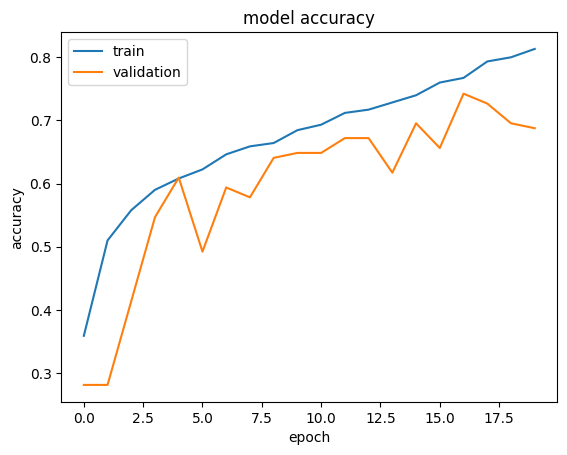

```python
# Plotting the training and validation accuracies for each epoch
N = len(cnn2_rgb_model_history.history["accuracy"])
#plt.figure(figsize = (10,6))
plt.plot(np.arange(0, N),cnn2_rgb_model_history.history['accuracy'])
plt.plot(np.arange(0, N),cnn2_rgb_model_history.history['val_accuracy'])
#plt.ylim(0, 1)
plt.title('model accuracy')
plt.ylabel('accuracy')
plt.xlabel('epoch')
plt.legend(['train', 'validation'], loc='upper left')
plt.show()
```

##### **Evaluating the Model on the Test Set**

```python
# Evaluating on the Test dataset
cnn2_rgb_model.evaluate(rgb_test_generator)
```

```
[0.7754190564155579, 0.703125]
```

**Observations and Insights:__**

## **Think About It:**

- Did the models have a satisfactory performance? If not, then what are the possible reasons?
- Which Color mode showed better overall performance? What are the possible reasons? Do you think having 'rgb' color mode is needed because the images are already black and white?

## **Transfer Learning Architectures**

In this section, we will create several Transfer Learning architectures. For the pre-trained models, we will select three popular architectures namely, VGG16, ResNet v2, and Efficient Net. The difference between these architectures and the previous architectures is that these will require 3 input channels while the earlier ones worked on 'grayscale' images. Therefore, we need to create new DataLoaders.

### **Creating our Data Loaders for Transfer Learning Architectures**

In this section, we are creating data loaders that we will use as inputs to our Neural Network. We will have to go with color_mode = 'rgb' as this is the required format for the transfer learning architectures.

```python
# data loaders for VGG
from tensorflow.keras.preprocessing.image import ImageDataGenerator, load_img, img_to_array
from tensorflow.keras.applications.vgg16 import preprocess_input

batch_size  = 128
img_size = 224

vgg_datagen_train = ImageDataGenerator(horizontal_flip = True,
                                      brightness_range=(0.,2.),
                                      rescale=1./255,
                                      shear_range=0.2,
                                      zoom_range=0.2,
                                       )

vgg_train_set = vgg_datagen_train.flow_from_directory("/content/Facial_emotion_images/train",
                                              target_size = (img_size, img_size),
                                              color_mode = "rgb" ,
                                              batch_size = batch_size,
                                              class_mode = 'categorical',
                                              shuffle = True)

vgg_datagen_val  = ImageDataGenerator(rescale = 1.0/255.)

vgg_validation_generator =  vgg_datagen_val.flow_from_directory("/content/Facial_emotion_images/validation",
                                                         batch_size=batch_size,
                                                        color_mode = "rgb" ,
                                                         class_mode  = 'categorical',
                                                         target_size = (img_size, img_size))

vgg_datagen_test  = ImageDataGenerator(rescale = 1.0/255.)

vgg_test_generator =  vgg_datagen_test.flow_from_directory("/content/Facial_emotion_images/test",
                                                         batch_size=batch_size,
                                                        color_mode = "rgb" ,
                                                         class_mode  = 'categorical',
                                                         target_size = (img_size, img_size))

def preprocess_input_vgg(x):
    x = preprocess_input(x)
    return x

# Apply the preprocessing function to the images after loading them
for X_batch, y_batch in vgg_train_set:
    X_batch = np.array([preprocess_input_vgg(img) for img in X_batch])
    # Now X_batch contains preprocessed images suitable for EfficientNet
    break

# Apply the preprocessing function to the images after loading them
for X_batch, y_batch in vgg_validation_generator:
    X_batch = np.array([preprocess_input_vgg(img) for img in X_batch])
    # Now X_batch contains preprocessed images suitable for EfficientNet
    break
```

```
Found 15109 images belonging to 4 classes.
Found 4977 images belonging to 4 classes.
Found 128 images belonging to 4 classes.
```

## **VGG16 Model**

#### **Importing the VGG16 Architecture**

```python
from tensorflow.keras.applications.vgg16 import VGG16
from tensorflow.keras import Model

vgg = VGG16(include_top = False, weights = 'imagenet', input_shape = (224, 224, 3))
vgg.summary()
```

```
Downloading data from https://storage.googleapis.com/tensorflow/keras-applications/vgg16/vgg16_weights_tf_dim_ordering_tf_kernels_notop.h5
Model: "vgg16"
_________________________________________________________________
 Layer (type)                Output Shape              Param #
=================================================================
 input_1 (InputLayer)        [(None, 224, 224, 3)]     0

 block1_conv1 (Conv2D)       (None, 224, 224, 64)      1792

 block1_conv2 (Conv2D)       (None, 224, 224, 64)      36928

 block1_pool (MaxPooling2D)  (None, 112, 112, 64)      0

 block2_conv1 (Conv2D)       (None, 112, 112, 128)     73856

 block2_conv2 (Conv2D)       (None, 112, 112, 128)     147584

 block2_pool (MaxPooling2D)  (None, 56, 56, 128)       0

 block3_conv1 (Conv2D)       (None, 56, 56, 256)       295168

 block3_conv2 (Conv2D)       (None, 56, 56, 256)       590080

 block3_conv3 (Conv2D)       (None, 56, 56, 256)       590080

 block3_pool (MaxPooling2D)  (None, 28, 28, 256)       0

 block4_conv1 (Conv2D)       (None, 28, 28, 512)       1180160

 block4_conv2 (Conv2D)       (None, 28, 28, 512)       2359808

 block4_conv3 (Conv2D)       (None, 28, 28, 512)       2359808

 block4_pool (MaxPooling2D)  (None, 14, 14, 512)       0

 block5_conv1 (Conv2D)       (None, 14, 14, 512)       2359808

 block5_conv2 (Conv2D)       (None, 14, 14, 512)       2359808

 block5_conv3 (Conv2D)       (None, 14, 14, 512)       2359808

 block5_pool (MaxPooling2D)  (None, 7, 7, 512)         0

=================================================================
Total params: 14714688 (56.13 MB)
Trainable params: 14714688 (56.13 MB)
Non-trainable params: 0 (0.00 Byte)
_________________________________________________________________
```

#### **Model Building**

- Import VGG16 upto the layer of your choice and add Fully Connected layers on top of it.

```python
vgg_output = vgg.get_layer('block5_pool')
vgg.trainable = False

# Flattenning the output from the VGG16 model
x = Flatten()(vgg_output.output)

# Adding a Dense layer with 256 neurons
x = Dense(256, activation = 'relu')(x)

# Add a Dense Layer with 128 neurons
x = Dense(128, activation = 'relu')(x)

# Add a DropOut layer with Drop out ratio of 0.3
x = Dropout(0.3)(x)

# Add a Dense Layer with 64 neurons
x = Dense(64, activation = 'relu')(x)

# Add a Batch Normalization layer
x = BatchNormalization()(x)

# Adding the final dense layer with 4 neurons and use 'softmax' activation
pred = Dense(4, activation='softmax')(x)

# Initializing the model
vgg_model = Model(vgg.input, pred)

# Generating the summary of the model
vgg_model.summary()
```

[output not shown]

#### **Compiling and Training the VGG16 Model**

```python
from keras.callbacks import ModelCheckpoint, EarlyStopping, ReduceLROnPlateau

# The following lines of code saves the best model's parameters if training accuracy goes down on further training
early_stopping = EarlyStopping(monitor = 'val_loss', mode = 'min', verbose = 1, patience = 3, min_delta = 0, restore_best_weights = True,)
checkpoint = ModelCheckpoint('best_model.h5', monitor = 'val_accuracy', mode = 'max', verbose = 1, save_best_only = True)
#reduce_learningrate = ReduceLROnPlateau(monitor = 'val_loss', factor = 0.2, patience = 3, verbose = 1, min_delta = 0.0001, mode = "min")

callbacks_list = [early_stopping, checkpoint]
```

```python
#Compiling the model using Adam Optimizer
opt = Adam(learning_rate = 0.001)

# Compiling the model
vgg_model.compile(optimizer = opt, loss = 'categorical_crossentropy', metrics = ['accuracy'])
```

```python
# Pulling a single large batch of random testing data for testing after each epoch
testX, testY = vgg_validation_generator.next()
```

```python
# Fit the model
vgg_history = vgg_model.fit(vgg_train_set,
                              validation_data=(testX, testY),
                                 epochs=30, #callbacks = callbacks_list
                                                        )
```

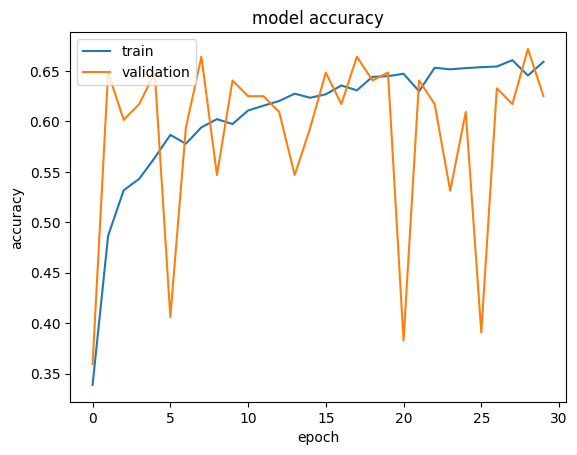

```python
# Plotting the training and validation accuracies for each epoch
N = len(vgg_history.history["accuracy"])
#plt.figure(figsize = (10,6))
plt.plot(np.arange(0, N),vgg_history.history['accuracy'])
plt.plot(np.arange(0, N),vgg_history.history['val_accuracy'])
#plt.ylim(0, 1)
plt.title('model accuracy')
plt.ylabel('accuracy')
plt.xlabel('epoch')
plt.legend(['train', 'validation'], loc='upper left')
plt.show()
```

#### **Evaluating the VGG16 model**

```python
# Evaluating on the Test dataset
vgg_model.evaluate(vgg_test_generator)
```

```
[0.9209996461868286, 0.609375]
```

**Observations and Insights:__**

From VGG16 model we can observe that validation accuracy is around 65% but with frequent drops in accuracy. Test accuracy is 60%.

**Think About It:**

- What do you infer from the general trend in the training performance?
- Is the training accuracy consistently improving?
- Is the validation accuracy also improving similarly?

**Note: You can even go back and build your own architecture on top of the VGG16 Transfer layer and see if you can improve the performance**

```python
import tensorflow as tf
import tensorflow.keras.applications as ap
from tensorflow.keras import Model

Resnet = ap.ResNet101(include_top = False, weights = "imagenet", input_shape=(224,224,3))
Resnet.summary()
```

```
Model: "resnet101"
__________________________________________________________________________________________________
 Layer (type)                Output Shape                 Param #   Connected to
==================================================================================================
 input_4 (InputLayer)        [(None, 224, 224, 3)]        0         []

 conv1_pad (ZeroPadding2D)   (None, 230, 230, 3)          0         ['input_4[0][0]']

 conv1_conv (Conv2D)         (None, 112, 112, 64)         9472      ['conv1_pad[0][0]']

 conv1_bn (BatchNormalizati  (None, 112, 112, 64)         256       ['conv1_conv[0][0]']
 on)

 conv1_relu (Activation)     (None, 112, 112, 64)         0         ['conv1_bn[0][0]']

 pool1_pad (ZeroPadding2D)   (None, 114, 114, 64)         0         ['conv1_relu[0][0]']

 pool1_pool (MaxPooling2D)   (None, 56, 56, 64)           0         ['pool1_pad[0][0]']

 conv2_block1_1_conv (Conv2  (None, 56, 56, 64)           4160      ['pool1_pool[0][0]']
 D)

 conv2_block1_1_bn (BatchNo  (None, 56, 56, 64)           256       ['conv2_block1_1_conv[0][0]']
 rmalization)

 conv2_block1_1_relu (Activ  (None, 56, 56, 64)           0         ['conv2_block1_1_bn[0][0]']
 ation)

 conv2_block1_2_conv (Conv2  (None, 56, 56, 64)           36928     ['conv2_block1_1_relu[0][0]']
 D)

 conv2_block1_2_bn (BatchNo  (None, 56, 56, 64)           256       ['conv2_block1_2_conv[0][0]']
 rmalization)

 conv2_block1_2_relu (Activ  (None, 56, 56, 64)           0         ['conv2_block1_2_bn[0][0]']
 ation)

 conv2_block1_0_conv (Conv2  (None, 56, 56, 256)          16640     ['pool1_pool[0][0]']
 D)

```

[output cut: 983 more lines]

```

 conv5_block3_3_bn (BatchNo  (None, 7, 7, 2048)           8192      ['conv5_block3_3_conv[0][0]']
 rmalization)

 conv5_block3_add (Add)      (None, 7, 7, 2048)           0         ['conv5_block2_out[0][0]',
                                                                     'conv5_block3_3_bn[0][0]']

 conv5_block3_out (Activati  (None, 7, 7, 2048)           0         ['conv5_block3_add[0][0]']
 on)

==================================================================================================
Total params: 42658176 (162.73 MB)
Trainable params: 42552832 (162.33 MB)
Non-trainable params: 105344 (411.50 KB)
__________________________________________________________________________________________________
```

```python
# data loaders for resnet
from tensorflow.keras.preprocessing.image import ImageDataGenerator, load_img, img_to_array
from tensorflow.keras.applications.resnet import preprocess_input
batch_size  = 128
img_size = 224

rgb_datagen_train = ImageDataGenerator(horizontal_flip = True,
                                    brightness_range=(0.,2.),
                                    rescale=1./255,
                                    shear_range=0.3)

rgb_train_set = rgb_datagen_train.flow_from_directory("/content/Facial_emotion_images/train",
                                              target_size = (img_size, img_size),
                                              color_mode = "rgb" ,
                                              batch_size = batch_size,
                                              class_mode = 'categorical',
                                              shuffle = True)

rgb_datagen_val  = ImageDataGenerator(rescale = 1.0/255.)

rgb_validation_generator =  rgb_datagen_val.flow_from_directory("/content/Facial_emotion_images/validation",
                                                         batch_size=batch_size,
                                                        color_mode = "rgb" ,
                                                         class_mode  = 'categorical',
                                                         target_size = (img_size, img_size))

rgb_datagen_test  = ImageDataGenerator(rescale = 1.0/255.)

rgb_test_generator =  rgb_datagen_test.flow_from_directory("/content/Facial_emotion_images/test",
                                                         batch_size=batch_size,
                                                        color_mode = "rgb" ,
                                                         class_mode  = 'categorical',
                                                         target_size = (img_size, img_size))
def preprocess_input_resnet(x):
    x = preprocess_input(x)
    return x

# Apply the preprocessing function to the images after loading them
for X_batch, y_batch in rgb_train_set:
    X_batch = np.array([preprocess_input_resnet(img) for img in X_batch])
    # Now X_batch contains preprocessed images suitable for EfficientNet
    break

# Apply the preprocessing function to the images after loading them
for X_batch, y_batch in rgb_validation_generator:
    X_batch = np.array([preprocess_input_resnet(img) for img in X_batch])
    # Now X_batch contains preprocessed images suitable for EfficientNet
    break
```

```
Found 15109 images belonging to 4 classes.
Found 4977 images belonging to 4 classes.
Found 128 images belonging to 4 classes.
```

### **Model Building**

```python
Resnet_output = Resnet.get_layer('conv5_block3_add')
Resnet.trainable=False

# Flattenning the output from the Resnet model
x = Flatten()(Resnet_output.output)

# Adding a Dense layer with 256 neurons
x = Dense(256, activation = 'relu')(x)

# Add a Dense Layer with 128 neurons
x = Dense(128, activation = 'relu')(x)

# Add a DropOut layer with Drop out ratio of 0.3
x = Dropout(0.3)(x)

# Add a Dense Layer with 64 neurons
x = Dense(64, activation = 'relu')(x)

# Add a Batch Normalization layer
x = BatchNormalization()(x)

# Add the final dense layer with 4 neurons and use a 'softmax' activation
pred = Dense(4, activation = 'softmax')(x)

resnetmodel = Model(Resnet.input, pred) # Initializing the model

# Generating the summary of the model
resnetmodel.summary()
```

```
Model: "model_1"
__________________________________________________________________________________________________
 Layer (type)                Output Shape                 Param #   Connected to
==================================================================================================
 input_2 (InputLayer)        [(None, 224, 224, 3)]        0         []

 conv1_pad (ZeroPadding2D)   (None, 230, 230, 3)          0         ['input_2[0][0]']

 conv1_conv (Conv2D)         (None, 112, 112, 64)         9472      ['conv1_pad[0][0]']

 conv1_bn (BatchNormalizati  (None, 112, 112, 64)         256       ['conv1_conv[0][0]']
 on)

 conv1_relu (Activation)     (None, 112, 112, 64)         0         ['conv1_bn[0][0]']

 pool1_pad (ZeroPadding2D)   (None, 114, 114, 64)         0         ['conv1_relu[0][0]']

 pool1_pool (MaxPooling2D)   (None, 56, 56, 64)           0         ['pool1_pad[0][0]']

 conv2_block1_1_conv (Conv2  (None, 56, 56, 64)           4160      ['pool1_pool[0][0]']
 D)

 conv2_block1_1_bn (BatchNo  (None, 56, 56, 64)           256       ['conv2_block1_1_conv[0][0]']
 rmalization)

 conv2_block1_1_relu (Activ  (None, 56, 56, 64)           0         ['conv2_block1_1_bn[0][0]']
 ation)

 conv2_block1_2_conv (Conv2  (None, 56, 56, 64)           36928     ['conv2_block1_1_relu[0][0]']
 D)

 conv2_block1_2_bn (BatchNo  (None, 56, 56, 64)           256       ['conv2_block1_2_conv[0][0]']
 rmalization)

 conv2_block1_2_relu (Activ  (None, 56, 56, 64)           0         ['conv2_block1_2_bn[0][0]']
 ation)

 conv2_block1_0_conv (Conv2  (None, 56, 56, 256)          16640     ['pool1_pool[0][0]']
 D)

```

[output cut: 997 more lines]

```
 dropout_1 (Dropout)         (None, 128)                  0         ['dense_5[0][0]']

 dense_6 (Dense)             (None, 64)                   8256      ['dropout_1[0][0]']

 batch_normalization_1 (Bat  (None, 64)                   256       ['dense_6[0][0]']
 chNormalization)

 dense_7 (Dense)             (None, 4)                    260       ['batch_normalization_1[0][0]'
                                                                    ]

==================================================================================================
Total params: 68390212 (260.89 MB)
Trainable params: 25731908 (98.16 MB)
Non-trainable params: 42658304 (162.73 MB)
__________________________________________________________________________________________________
```

### **Compiling and Training the Model**

```python
from keras.callbacks import ModelCheckpoint, EarlyStopping, ReduceLROnPlateau

# The following lines of code saves the best model's parameters if training accuracy goes down on further training
early_stopping = EarlyStopping(monitor = 'val_loss', mode = 'min', verbose = 1, patience = 3, min_delta = 0, restore_best_weights = True,)
checkpoint = ModelCheckpoint('best_model.h5', monitor = 'val_accuracy', mode = 'max', verbose = 1, save_best_only = True)
reduce_learningrate = ReduceLROnPlateau(monitor = 'val_loss', factor = 0.2, patience = 3, verbose = 1, min_delta = 0.0001, mode = "min")

callbacks_list = [early_stopping, checkpoint, reduce_learningrate]
```

```python
#Compiling the model using Adam Optimizer
opt = Adam(learning_rate = 0.001)

# Compiling the model
resnetmodel.compile(optimizer = opt, loss = 'categorical_crossentropy', metrics = ['accuracy'])
```

```python
# Pulling a single large batch of random testing data for testing after each epoch
testX, testY = rgb_validation_generator.next()
```

```python
# Fit the model
resnet_history = resnetmodel.fit(rgb_train_set,
                              validation_data=(testX, testY),
                              epochs=30)
```

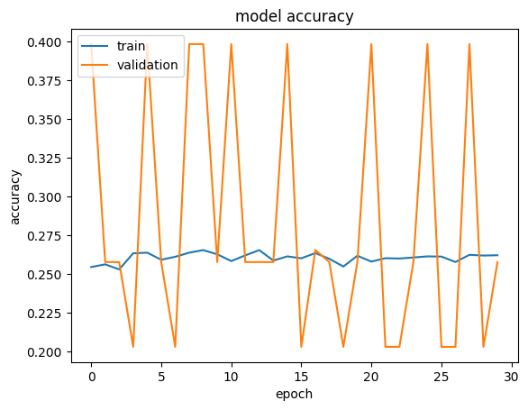

```python
# Plotting the training and validation accuracies for each epoch
N = len(resnet_history.history["accuracy"])
#plt.figure(figsize = (10,6))
plt.plot(np.arange(0, N),resnet_history.history['accuracy'])
plt.plot(np.arange(0, N),resnet_history.history['val_accuracy'])
#plt.ylim(0, 1)
plt.title('model accuracy')
plt.ylabel('accuracy')
plt.xlabel('epoch')
plt.legend(['train', 'validation'], loc='upper left')
plt.show()
```

### **Evaluating the ResNet Model**

```python
# Evaluating on the Test dataset
resnetmodel.evaluate(rgb_test_generator)
```

```
[1.3884059190750122, 0.25]
```

**Observations and Insights:__**

From ReseNet model we can observe that validation accuracy is around 25% that fluctuates as lot. Test accuracy is 25%.

## **EfficientNet Model**

#### **Importing the EfficientNet Architecture**

```python
import tensorflow as tf
import tensorflow.keras.applications as ap
from tensorflow.keras import Model
EfficientNet = ap.EfficientNetV2B2(include_top=False,weights="imagenet", input_shape= (224, 224, 3), classes=4)

EfficientNet.summary()
```

```
Model: "efficientnetv2-b2"
__________________________________________________________________________________________________
 Layer (type)                Output Shape                 Param #   Connected to
==================================================================================================
 input_5 (InputLayer)        [(None, 224, 224, 3)]        0         []

 rescaling_1 (Rescaling)     (None, 224, 224, 3)          0         ['input_5[0][0]']

 normalization_1 (Normaliza  (None, 224, 224, 3)          0         ['rescaling_1[0][0]']
 tion)

 stem_conv (Conv2D)          (None, 112, 112, 32)         864       ['normalization_1[0][0]']

 stem_bn (BatchNormalizatio  (None, 112, 112, 32)         128       ['stem_conv[0][0]']
 n)

 stem_activation (Activatio  (None, 112, 112, 32)         0         ['stem_bn[0][0]']
 n)

 block1a_project_conv (Conv  (None, 112, 112, 16)         4608      ['stem_activation[0][0]']
 2D)

 block1a_project_bn (BatchN  (None, 112, 112, 16)         64        ['block1a_project_conv[0][0]']
 ormalization)

 block1a_project_activation  (None, 112, 112, 16)         0         ['block1a_project_bn[0][0]']
  (Activation)

 block1b_project_conv (Conv  (None, 112, 112, 16)         2304      ['block1a_project_activation[0
 2D)                                                                ][0]']

 block1b_project_bn (BatchN  (None, 112, 112, 16)         64        ['block1b_project_conv[0][0]']
 ormalization)

 block1b_project_activation  (None, 112, 112, 16)         0         ['block1b_project_bn[0][0]']
  (Activation)

 block1b_drop (Dropout)      (None, 112, 112, 16)         0         ['block1b_project_activation[0
                                                                    ][0]']

```

[output cut: 937 more lines]

```
                                                                     'block6i_add[0][0]']

 top_conv (Conv2D)           (None, 7, 7, 1408)           292864    ['block6j_add[0][0]']

 top_bn (BatchNormalization  (None, 7, 7, 1408)           5632      ['top_conv[0][0]']
 )

 top_activation (Activation  (None, 7, 7, 1408)           0         ['top_bn[0][0]']
 )

==================================================================================================
Total params: 8769374 (33.45 MB)
Trainable params: 8687086 (33.14 MB)
Non-trainable params: 82288 (321.44 KB)
__________________________________________________________________________________________________
```

### **Model Building**

- Import EfficientNet upto the layer of your choice and add Fully Connected layers on top of it.

```python
from tensorflow.keras.preprocessing.image import ImageDataGenerator, load_img, img_to_array
from tensorflow.keras.applications.efficientnet import preprocess_input
batch_size  = 128
img_size = 224

effnet_datagen_train = ImageDataGenerator(
                                    #preprocessing_function=normalize_to_minus_one_one,
                                    rotation_range=20,
                                    width_shift_range=0.2,
                                    height_shift_range=0.2,
                                    zoom_range=0.2,
                                    horizontal_flip=True,
                                    fill_mode='nearest',
                                    brightness_range=(0.,2.),
                                    rescale=1./255,
                                    shear_range=0.3)

effnet_train_set = effnet_datagen_train.flow_from_directory("/content/Facial_emotion_images/train",
                                              target_size = (img_size, img_size),
                                              color_mode = "rgb" ,
                                              batch_size = batch_size,
                                              class_mode = 'categorical',
                                              shuffle = True)

effnet_datagen_val  = ImageDataGenerator(rescale = 1.0/255.)

effnet_validation_generator =  effnet_datagen_val.flow_from_directory("/content/Facial_emotion_images/validation",
                                                         batch_size=batch_size,
                                                        color_mode = "rgb" ,
                                                         class_mode  = 'categorical',
                                                         target_size = (img_size, img_size))

effnet_datagen_test  = ImageDataGenerator(rescale = 1.0/255.)

effnet_test_generator =  effnet_datagen_test.flow_from_directory("/content/Facial_emotion_images/test",
                                                         batch_size=batch_size,
                                                        color_mode = "rgb" ,
                                                         class_mode  = 'categorical',
                                                         target_size = (img_size, img_size))
def preprocess_input_effnet(x):
    x = preprocess_input(x)
    return x

# Apply the preprocessing function to the images after loading them
for X_batch, y_batch in effnet_train_set:
    X_batch = np.array([preprocess_input_effnet(img) for img in X_batch])
    # Now X_batch contains preprocessed images suitable for EfficientNet
    break

# Apply the preprocessing function to the images after loading them
for X_batch, y_batch in effnet_validation_generator:
    X_batch = np.array([preprocess_input_effnet(img) for img in X_batch])
    # Now X_batch contains preprocessed images suitable for EfficientNet
    break
```

```
Found 15109 images belonging to 4 classes.
Found 4977 images belonging to 4 classes.
Found 128 images belonging to 4 classes.
```

```python
EfficientNet_output = EfficientNet.get_layer('block6e_expand_activation')
EfficientNet.trainable = False

# Flattenning the output from the EfficientNet model
x = Flatten()(EfficientNet_output.output)

# Adding a Dense layer with 256 neurons
x = Dense(256, activation = 'relu')(x)

# Add a Dense Layer with 128 neurons
x = Dense(128, activation = 'relu')(x)

# Add a DropOut layer with Drop out ratio of 0.3
x = Dropout(0.3)(x)

# Add a Dense Layer with 64 neurons
x = Dense(64, activation = 'relu')(x)

# Add a Batch Normalization layer
x = BatchNormalization()(x)

# Add the final dense layer with 4 neurons and use a 'softmax' activation
pred = Dense(4, activation = 'softmax')(x)

# Add your final Dense layer with 4 neurons and softmax activation function.

Efficientnetmodel = Model(EfficientNet.input, pred)

# Generating the summary of the model
Efficientnetmodel.summary()
```

```
Model: "model_4"
__________________________________________________________________________________________________
 Layer (type)                Output Shape                 Param #   Connected to
==================================================================================================
 input_5 (InputLayer)        [(None, 224, 224, 3)]        0         []

 rescaling_1 (Rescaling)     (None, 224, 224, 3)          0         ['input_5[0][0]']

 normalization_1 (Normaliza  (None, 224, 224, 3)          0         ['rescaling_1[0][0]']
 tion)

 stem_conv (Conv2D)          (None, 112, 112, 32)         864       ['normalization_1[0][0]']

 stem_bn (BatchNormalizatio  (None, 112, 112, 32)         128       ['stem_conv[0][0]']
 n)

 stem_activation (Activatio  (None, 112, 112, 32)         0         ['stem_bn[0][0]']
 n)

 block1a_project_conv (Conv  (None, 112, 112, 16)         4608      ['stem_activation[0][0]']
 2D)

 block1a_project_bn (BatchN  (None, 112, 112, 16)         64        ['block1a_project_conv[0][0]']
 ormalization)

 block1a_project_activation  (None, 112, 112, 16)         0         ['block1a_project_bn[0][0]']
  (Activation)

 block1b_project_conv (Conv  (None, 112, 112, 16)         2304      ['block1a_project_activation[0
 2D)                                                                ][0]']

 block1b_project_bn (BatchN  (None, 112, 112, 16)         64        ['block1b_project_conv[0][0]']
 ormalization)

 block1b_project_activation  (None, 112, 112, 16)         0         ['block1b_project_bn[0][0]']
  (Activation)

 block1b_drop (Dropout)      (None, 112, 112, 16)         0         ['block1b_project_activation[0
                                                                    ][0]']

```

[output cut: 704 more lines]

```
 dropout_4 (Dropout)         (None, 128)                  0         ['dense_17[0][0]']

 dense_18 (Dense)            (None, 64)                   8256      ['dropout_4[0][0]']

 batch_normalization_4 (Bat  (None, 64)                   256       ['dense_18[0][0]']
 chNormalization)

 dense_19 (Dense)            (None, 4)                    260       ['batch_normalization_4[0][0]'
                                                                    ]

==================================================================================================
Total params: 20398442 (77.81 MB)
Trainable params: 15696708 (59.88 MB)
Non-trainable params: 4701734 (17.94 MB)
__________________________________________________________________________________________________
```

### **Compiling and Training the Model**

```python
from keras.callbacks import ModelCheckpoint, EarlyStopping, ReduceLROnPlateau

# The following lines of code saves the best model's parameters if training accuracy goes down on further training
early_stopping = EarlyStopping(monitor = 'val_loss', mode = 'min', verbose = 1, patience = 3, min_delta = 0, restore_best_weights = True,)
checkpoint = ModelCheckpoint('best_model.h5', monitor = 'val_accuracy', mode = 'max', verbose = 1, save_best_only = True)
reduce_learningrate = ReduceLROnPlateau(monitor = 'val_loss', factor = 0.2, patience = 3, verbose = 1, min_delta = 0.0001, mode = "min")

callbacks_list = [early_stopping, checkpoint, reduce_learningrate]
```

```python
#Compiling the model using Adam Optimizer
opt = Adam(learning_rate = 0.001)

# Compiling the model
Efficientnetmodel.compile(optimizer = opt, loss = 'categorical_crossentropy', metrics = ['accuracy'])
```

```python
# Pulling a single large batch of random testing data for testing after each epoch
testX, testY = effnet_validation_generator.next()
```

```python
# Fit the model
Efficientnet_history = Efficientnetmodel.fit(effnet_train_set,
                              validation_data=(testX, testY),
                              epochs=30)
```

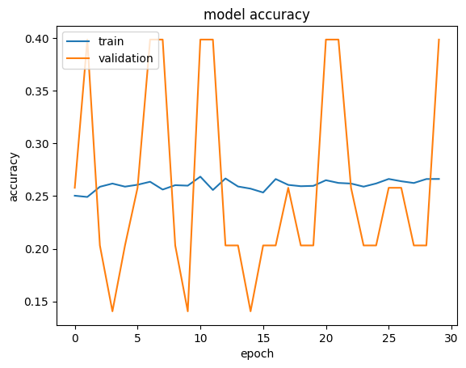

```python
# Plotting the training and validation accuracies for each epoch
N = len(Efficientnet_history.history["accuracy"])
#plt.figure(figsize = (10,6))
plt.plot(np.arange(0, N),Efficientnet_history.history['accuracy'])
plt.plot(np.arange(0, N),Efficientnet_history.history['val_accuracy'])
#plt.ylim(0, 1)
plt.title('model accuracy')
plt.ylabel('accuracy')
plt.xlabel('epoch')
plt.legend(['train', 'validation'], loc='upper left')
plt.show()
```

### **Evaluating the EfficientnetNet Model**

```python
# Evaluating on the Test dataset
Efficientnetmodel.evaluate(effnet_test_generator)
```

```
[1.3901420831680298, 0.25]
```

**Observations and Insights:__**

From EfficientNet model we can observe that validation accuracy fluctuates a lot. Test accuracy is 25%.

**Think About It:**

- What is your overall performance of these Transfer Learning Architectures? Can we draw a comparison of these models' performances. Are we satisfied with the accuracies that we have received?
- Do you think our issue lies with 'rgb' color_mode?

Now that we have tried multiple pre-trained models, let's build a complex CNN architecture and see if we can get better performance.

## **Building a Complex Neural Network Architecture**

### **Creating our Data Loaders**

In this section, we are creating data loaders which we will use as inputs to the more Complicated Convolutional Neural Network. We will go ahead with color_mode = 'grayscale'.

```python
# data loaders
batch_size  = 128
img_size = 48

datagen_train  = ImageDataGenerator(rotation_range=20,
                                    width_shift_range=0.2,
                                    height_shift_range=0.2,
                                    shear_range=0.2,
                                    zoom_range=0.2,
                                    horizontal_flip=True,
                                    fill_mode='nearest',
                                    rescale = 1./255)

train_set = datagen_train.flow_from_directory("/content/Facial_emotion_images/train",
                                              target_size = (img_size, img_size),
                                              color_mode = "grayscale" ,
                                              batch_size = batch_size,
                                              class_mode = 'categorical',
                                              shuffle = True)

datagen_val  = ImageDataGenerator(rescale = 1./255)

validation_generator =  datagen_val.flow_from_directory("/content/Facial_emotion_images/validation",
                                                         batch_size=batch_size,
                                                         color_mode = "grayscale" ,
                                                         class_mode  = 'categorical',
                                                         target_size = (img_size, img_size),
                                                        )

datagen_test  = ImageDataGenerator(rescale = 1./255)

test_generator =  datagen_test.flow_from_directory("/content/Facial_emotion_images/test",
                                                         batch_size=batch_size,
                                                         color_mode = "grayscale" ,
                                                         class_mode  = 'categorical',
                                                         target_size = (img_size, img_size),
                                                   )
```

```
Found 15109 images belonging to 4 classes.
Found 4977 images belonging to 4 classes.
Found 128 images belonging to 4 classes.
```

### **Model Building**

- Try building a layer with 5 Convolutional Blocks and see if performance increases.

```python
from tensorflow.keras import backend
backend.clear_session()

# Fixing the seed for random number generators so that we can ensure we receive the same output everytime
np.random.seed(42)
import random
random.seed(42)
tf.random.set_seed(42)
```

```python
# Intializing a sequential model
cnn_model = Sequential()

# Adding first conv layer with 32 filters and kernel size 2x2, padding 'same'
cnn_model.add(Conv2D(32, (2, 2), activation = 'relu',  padding = "same", input_shape = (48, 48, 1)))
cnn_model.add(BatchNormalization())
cnn_model.add(LeakyReLU(0.1))
cnn_model.add(MaxPooling2D((2, 2), padding = 'same'))
cnn_model.add(Dropout(0.2))

# Adding second conv layer with 64 filters
cnn_model.add(Conv2D(64, (2, 2), activation = 'relu', padding = "same"))
cnn_model.add(BatchNormalization())
cnn_model.add(LeakyReLU(0.1))
cnn_model.add(MaxPooling2D((2, 2), padding = 'same'))
cnn_model.add(Dropout(0.2))

# Add third conv layer with 128 filters
cnn_model.add(Conv2D(128, (2, 2), activation = 'relu', padding = "same"))
cnn_model.add(BatchNormalization())
cnn_model.add(LeakyReLU(0.1))
cnn_model.add(MaxPooling2D((2, 2), padding = 'same'))
cnn_model.add(Dropout(0.2))

# Add third conv layer with 256 filters
cnn_model.add(Conv2D(256, (2, 2), activation = 'relu', padding = "same"))
cnn_model.add(BatchNormalization())
cnn_model.add(LeakyReLU(0.1))
cnn_model.add(MaxPooling2D((2, 2), padding = 'same'))
cnn_model.add(Dropout(0.2))

# Add third conv layer with 512 filters
cnn_model.add(Conv2D(512, (2, 2), activation = 'relu', padding = "same"))
cnn_model.add(BatchNormalization())
cnn_model.add(LeakyReLU(0.1))
cnn_model.add(MaxPooling2D((2, 2), padding = 'same'))
cnn_model.add(Dropout(0.2))

# Flattening the output of the conv layer after max pooling to make it ready for creating dense connections
cnn_model.add(Flatten())

# Adding a fully connected dense layer with 512 neurons
cnn_model.add(Dense(512))
cnn_model.add(BatchNormalization())
cnn_model.add(LeakyReLU(0.1))
cnn_model.add(Dropout(0.4))

# Adding a fully connected dense layer with 128 neurons
cnn_model.add(Dense(128))
cnn_model.add(BatchNormalization())
cnn_model.add(LeakyReLU(0.1))
cnn_model.add(Dropout(0.2))

# Adding the output layer with 4 neurons and activation functions as softmax since this is a multi-class classification problem
cnn_model.add(Dense(4, activation = 'softmax'))

# Generating the summary of the model
cnn_model.summary()
```

```
Model: "sequential"
_________________________________________________________________
 Layer (type)                Output Shape              Param #
=================================================================
 conv2d (Conv2D)             (None, 48, 48, 32)        160

 batch_normalization_5 (Bat  (None, 48, 48, 32)        128
 chNormalization)

 leaky_re_lu (LeakyReLU)     (None, 48, 48, 32)        0

 max_pooling2d (MaxPooling2  (None, 24, 24, 32)        0
 D)

 dropout_5 (Dropout)         (None, 24, 24, 32)        0

 conv2d_1 (Conv2D)           (None, 24, 24, 64)        8256

 batch_normalization_6 (Bat  (None, 24, 24, 64)        256
 chNormalization)

 leaky_re_lu_1 (LeakyReLU)   (None, 24, 24, 64)        0

 max_pooling2d_1 (MaxPoolin  (None, 12, 12, 64)        0
 g2D)

 dropout_6 (Dropout)         (None, 12, 12, 64)        0

 conv2d_2 (Conv2D)           (None, 12, 12, 128)       32896

 batch_normalization_7 (Bat  (None, 12, 12, 128)       512
 chNormalization)

 leaky_re_lu_2 (LeakyReLU)   (None, 12, 12, 128)       0

 max_pooling2d_2 (MaxPoolin  (None, 6, 6, 128)         0
 g2D)

 dropout_7 (Dropout)         (None, 6, 6, 128)         0

```

[output cut: 36 more lines]

```

 batch_normalization_11 (Ba  (None, 128)               512
 tchNormalization)

 leaky_re_lu_6 (LeakyReLU)   (None, 128)               0

 dropout_11 (Dropout)        (None, 128)               0

 dense_22 (Dense)            (None, 4)                 516

=================================================================
Total params: 1819236 (6.94 MB)
Trainable params: 1815972 (6.93 MB)
Non-trainable params: 3264 (12.75 KB)
_________________________________________________________________
```

### **Compiling and Training the Model**

```python
from keras.callbacks import ModelCheckpoint, EarlyStopping, ReduceLROnPlateau

# The following lines of code saves the best model's parameters if training accuracy goes down on further training
early_stopping = EarlyStopping(monitor = 'val_loss', mode = 'min', verbose = 1, patience = 3, min_delta = 0, restore_best_weights = True,)
checkpoint = ModelCheckpoint('best_model.h5', monitor = 'val_accuracy', mode = 'max', verbose = 1, save_best_only = True)
#reduce_learningrate = ReduceLROnPlateau(monitor = 'val_loss', factor = 0.2, patience = 3, verbose = 1, min_delta = 0.0001, mode = "min")

callbacks_list = [early_stopping, checkpoint]
```

```python
#Compiling the model using Adam Optimizer
opt = Adam(learning_rate = 0.001)

# Compiling the model
cnn_model.compile(optimizer = opt, loss = 'categorical_crossentropy', metrics = ['accuracy'])
```

```python
# Pulling a single large batch of random testing data for testing after each epoch
testX, testY = validation_generator.next()
```

```python
# Fit the model
cnn_model_history = cnn_model.fit(train_set,
                              validation_data=(testX, testY),
                              epochs=30)
```

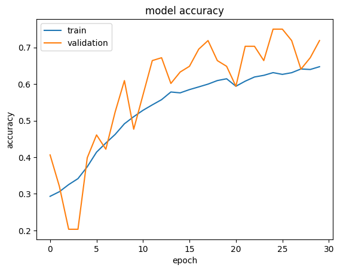

```python
# Plotting the training and validation accuracies for each epoch
N = len(cnn_model_history.history["accuracy"])
#plt.figure(figsize = (10,6))
plt.plot(np.arange(0, N),cnn_model_history.history['accuracy'])
plt.plot(np.arange(0, N),cnn_model_history.history['val_accuracy'])
#plt.ylim(0, 1)
plt.title('model accuracy')
plt.ylabel('accuracy')
plt.xlabel('epoch')
plt.legend(['train', 'validation'], loc='upper left')
plt.show()
```

### **Evaluating the Model on Test Set**

```python
# Evaluating on the Test dataset
cnn_model.evaluate(test_generator)
```

```
[0.6248895525932312, 0.734375]
```

**Observations and Insights:__**

From the complex CNN model, we can observe validation accuracy of around 71%. The test accuracy shows 73% on evaluation.

### **Plotting the Confusion Matrix for the chosen final model**

```
Found 128 images belonging to 4 classes.
              precision    recall  f1-score   support

           0       0.81      0.81      0.81        32
           1       0.35      0.47      0.40        32
           2       0.17      0.12      0.15        32
           3       0.90      0.84      0.87        32

    accuracy                           0.56       128
   macro avg       0.56      0.56      0.56       128
weighted avg       0.56      0.56      0.56       128
```

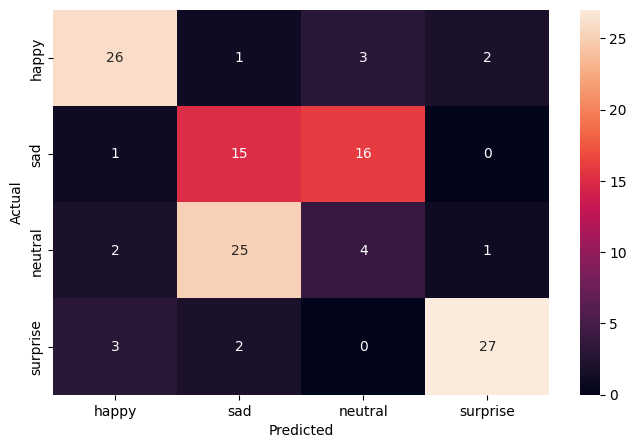

```python
# Plot the confusion matrix and generate a classification report for the model
from sklearn.metrics import classification_report
from sklearn.metrics import confusion_matrix
test_set = datagen_test.flow_from_directory("/content/Facial_emotion_images/test",
                                                              target_size = (img_size,img_size),
                                                              color_mode = 'grayscale',
                                                              batch_size = 128,
                                                              class_mode = 'categorical',
                                                              classes = ['happy', 'sad', 'neutral', 'surprise'],
                                                              shuffle = True)
test_images, test_labels = next(test_set)

# Write the name of your chosen model in the blank
pred = cnn_model.predict(test_images)
pred = np.argmax(pred, axis = 1)
y_true = np.argmax(test_labels, axis = 1)

# Printing the classification report
print(classification_report(y_true,pred))

# Plotting the heatmap using confusion matrix
cm = confusion_matrix(y_true, pred)
plt.figure(figsize = (8, 5))
sns.heatmap(cm, annot = True,  fmt = '.0f', xticklabels = ['happy', 'sad', 'neutral', 'surprise'], yticklabels = ['happy', 'sad', 'neutral', 'surprise'])
plt.ylabel('Actual')
plt.xlabel('Predicted')
plt.show()
```

```python
import numpy as np

# Make predictions on the test set
predictions = cnn_model.predict(test_images)

# Convert the predictions to class labels
predicted_labels = np.argmax(predictions, axis=1)

# Assuming you have the true labels for the test set
true_labels = np.argmax(test_labels, axis=1)  # Assuming y_test is one-hot encoded

# Compare predicted labels with true labels
for i in range(len(test_images)):
   print(f"Image {i + 1}: Predicted Label: {predicted_labels[i]}, True Label: {true_labels[i]}")
```

[output not shown]

[output cut: 73 more lines]

[output not shown]

**Observations and Insights:__**

From the confusion matrix, the accuracy is around 56%.

## **Conclusion:*__***

### **Refined insights**:

- The train dataset has some misclassifications, which is causing the validation and test data accuracy to reduce.

### **Proposal for the final solution design**:

- I will propose the last model (cnn_model) as it provides a decent accuracy, with the dataset that has some misclassifications.